# Helping the scum of the earth

### J. Thatcher

https://jhuria.wordpress.com/2012/07/01/text-mining-in-r/

### Background

Some have proposed machine learning as a solution to predict legal outcomes, which could eventually lessen the burdeon on these attourneys ([ref.](http://citeseerx.ist.psu.edu/viewdoc/download?doi=10.1.1.85.9499&rep=rep1&type=pdf)). The goal would be to automate the lawyer’s thinking processes and determien the proper pathway for each case with the support of a computer. Unfortunatly, it is clear that science lacks the ability to mimick the complex thought patterns of an attourney. However, this does not preclude the use of machine learning in law. In fact, some have proposed that machine learning could be a valuable tool to perform the simpler decision proceses of an attourney in a rapid and accurate way. For instance, a machine learning model could be used to predict the liklihood of succes or failure in the event of a guilty or not-guilty plea for certain crimes.

Of particular interest may be the following problem outined by the [Washington Law Review](https://digital.law.washington.edu/dspace-law/bitstream/handle/1773.1/1321/89WLR0087.pdf):

“The ability to make informed and useful predictions about potential legal outcomes and liability is one of the primary skills of lawyering. Lawyers are routinely called upon to make predictions in a variety of legal settings. In a typical scenario, a client may provide the lawyer with a legal problem involving a complex set of facts and goals. A lawyer might employ a combination of judgment, experience, and knowledge of the law to make reasoned predictions about the likelihood of outcomes on particular legal issues or on overall issue of liability, often in contexts of considerable legal and factual uncertainty. On the basis of these predictions and other factors, the lawyer might counsel the client about recommended courses of action.”

In particular I would consider focusing on predicting the legal outocme of a case based on the documentatation provided to the lawer duirng the discovery process. This would be useful to accurately and quickly allow the publick defender to counsel the client about a recommended courses of action.

### Purpose

The purpouse is to verify that Machine Learning or Pattern Recognition could be used to reduce the burden of work for a public defender. To do this, we will attempt to accurately predict the outcome of cases based on their court documents and then identify which content has a significant impact on the outcome of the case.

### Data

The UCI has a database on court cases in Australia that can be used as data to approach this problem. This dataset contains Australian legal cases from the Federal Court of Australia (FCA) from 2006 - 2009.

```r
download.file("https://archive.ics.uci.edu/ml/machine-learning-databases/00239/corpus.zip", "C:/Users/jeffthatcher/Downloads/corpus.zip")
unzip("C:/Users/jeffthatcher/Downloads/corpus.zip", exdir = "C:/Users/jeffthatcher/Cloud Drive/RRepos/Law_DataSet/")
```

Let’s get started with cleaning the data. It’s in html, and we want to grab the body text and re-format it to text documents for generating a documet-term matrix.

```r
setwd("C:/Users/jeffthatcher/Cloud Drive/RRepos/Law_DataSet/corpus")
library(XML)

### Set Data Directory, find content files, and set a directory for writing the text files.
dir <- "C:/Users/jeffthatcher/Cloud Drive/RRepos/Law_DataSet/corpus/Classified"
list <- dir(dir, full.names = TRUE, recursive = FALSE)
writeTextLoc <- gsub("Classified", "Classified/asText", list)

### Load data, remove "catchphrases" developed by previous ML group, and convert to text files

doc <- rep(1, (length(list)-1))
titles <- rep(1, (length(list)-1))

for (i in 1:(length(list)-1)){
        doc <- htmlTreeParse(list[i], useInternal=TRUE)
        #Write body as text
        sentences <- xpathSApply(doc, "//sentences", xmlValue, trim = TRUE)
        bodyTextLoc <- gsub(".xml", "_sentences.txt", writeTextLoc[i])
        write(sentences, file = bodyTextLoc)
        #Capture case titles
        title.temp <- xpathSApply(doc, "//name", xmlValue, trim = TRUE)
        titles[i] <- c(title.temp)
        #titleTextLoc <- gsub(".xml", "_title.txt", writeTextLoc[i])
        #write(title, file = titleTextLoc)
}
```

Now we can read the text douments in and create a term-document matrix.

```r
###Convert into term-document matrix
library(tm)
```

```r
### Clean Text Function
cleanCorpus <- function(corpus) {
        corpus.tmp <- tm_map(corpus, removePunctuation)
        corpus.tmp <- tm_map(corpus.tmp, stripWhitespace)
        corpus.tmp <- tm_map(corpus.tmp, content_transformer(tolower))
        corpus.tmp <- tm_map(corpus.tmp, removeWords, stopwords("english"))
        return(corpus.tmp)
}

textDir <- "C:/Users/jeffthatcher/Cloud Drive/RRepos/Law_DataSet/corpus/Classified/asText"

corp.raw <- VCorpus(DirSource(directory = textDir), readerControl = list(reader=readPlain))
corp.raw <- cleanCorpus(corp.raw)

### Build a term document matrix
corp.dtm <- DocumentTermMatrix(corp.raw)
```

### Methods

Alright, now lets look at some simple descritive stats from the data

1. We will calculate the word frequencies for our words

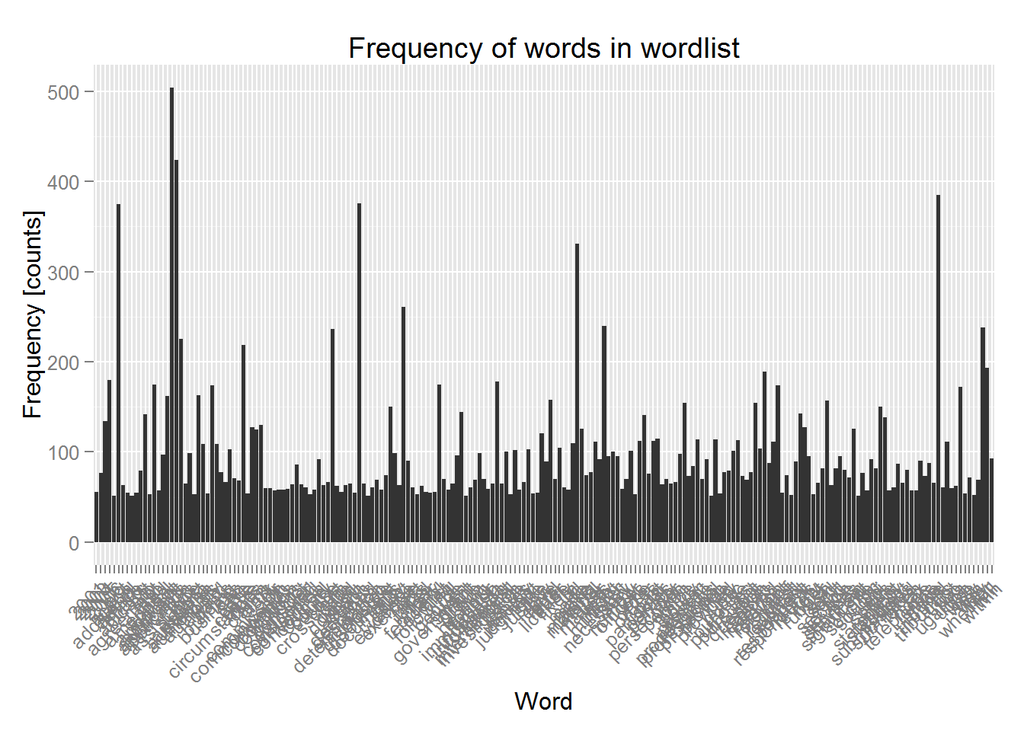

```r
library(ggplot2)
### Conver Term Document Matrix Into Data Frame
freq <- colSums(as.matrix(corp.dtm))

wf <- data.frame(word=names(freq), freq=freq)

p <- ggplot(subset(wf, freq>50), aes(word, freq)) +
        geom_bar(stat="identity") +
        theme(axis.text.x=element_text(angle=45, hjust=1)) +
        labs(title = "Frequency of words in wordlist",x="Word", y="Frequency [counts]")
p
```

2. Lets look at some clustering to find any obvious categories in the dataset  
-try a dendrogram first  
-second we will use k-means clustering

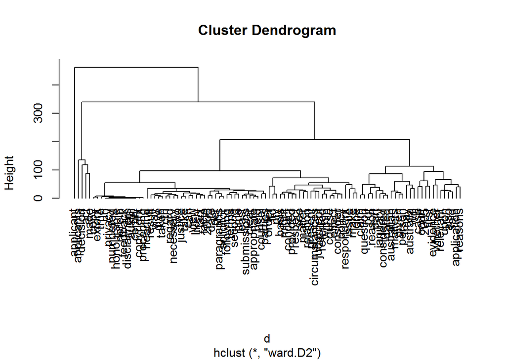

```r
### Eliminate Sparse Terms
dtm.sparse <- removeSparseTerms(corp.dtm, 0.2) # This makes a matrix that is only 20% empty space, maximum.

### Heirarchical Clustering library(cluster)
d <- dist(t(dtm.sparse), method="euclidian")
fit <- hclust(d=d, method="ward.D2")
plot(fit, hang=-1)
```

```r
library(cluster)
```

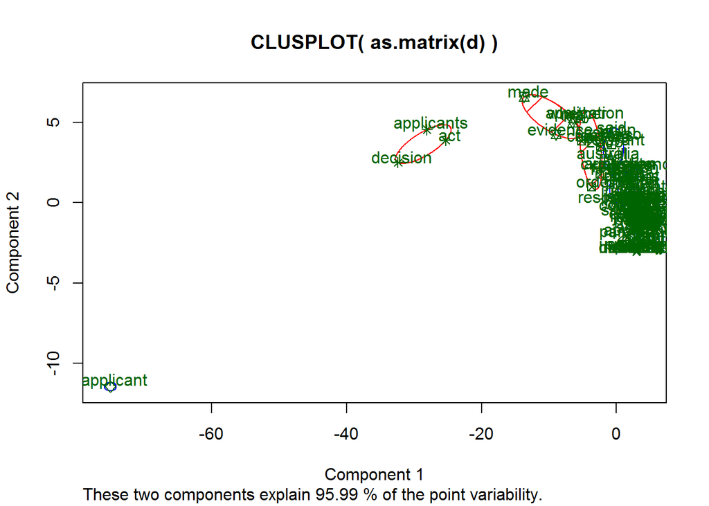

```r
## k-means clustering library(fpc)
d <- dist(t(dtm.sparse), method="euclidian")
kfit <- kmeans(d, 12)
clusplot(as.matrix(d), kfit$cluster, color=T, shade=T, labels=3, lines=0)
```